# Proyecto asignatura Estadística (MAT3) GIN2 Grupos 1 y 3: PARTE 2. Curso 2020-2021

Antoni, Pol Martínez; Josep, Oliver Vallespir; Gabriel, Riutort Álvarez

15/06/2021

A mi grupo le ha tocado de la web [web de Airbnb](http://insideairbnb.com/get-the-data.html), Madrid, Ciudad de Madrid, España.

# 1 Parte 2: Estadística Inferencial

Supongamos que los datos de la ciudad que ha sido asignada a cada grupo corresponden a una muestra aleatoria simple de todas las viviendas que se podrían alquilar en la ciudad. Utilizando esta muestra se pide:

## 1.1 Carga de datos

Cargamos los datos.

Los datos son:

```r
str(df_Madrid)
```

```
## tibble[,11] [8,708 x 11] (S3: tbl_df/tbl/data.frame)
##  $ Vecindario                      : chr [1:8708] "Madrid, Spain" "Madrid, Comunidad de Madrid, Spain" "Madrid, Spain" "Madrid, Spain" ...
##  $ Nombre_anfitrion                : chr [1:8708] "Abdel" "Agustina" "Patricia" "Arturo" ...
##  $ Localizacion_anfitrion          : chr [1:8708] "Madrid, Madrid, Spain" "Madrid, Madrid, Spain" "Madrid, Community of Madrid, Spain" "Madrid, Community of Madrid, Spain" ...
##  $ Precio                          : num [1:8708] 31 26 40 58 21 51 54 75 80 44 ...
##  $ ID                              : num [1:8708] 21853 26825 59923 62423 64131 ...
##  $ Dormitorios                     : num [1:8708] 1 1 1 1 1 1 1 2 1 1 ...
##  $ Camas                           : num [1:8708] 1 1 1 2 1 1 3 2 2 1 ...
##  $ Recuento_total_listado_anfitrion: num [1:8708] 2 1 1 2 3 3 6 6 1 1 ...
##  $ Acomodados                      : num [1:8708] 1 1 1 3 2 2 4 3 4 2 ...
##  $ Maximo_de_noches                : num [1:8708] 40 1125 30 90 1125 ...
##  $ Ratio_de_Revisiones_Puntuaciones: num [1:8708] 92 94 99 91 95 97 83 80 92 93 ...
##  - attr(*, "na.action")= 'omit' Named int [1:11448] 1 3 4 5 7 8 9 10 11 12 ...
##   ..- attr(*, "names")= chr [1:11448] "1" "3" "4" "5" ...
```

## 1.2 Solución ejercicio 1

1. Calcular una estimación puntual de la media para la variable `price` y el error estándar del estimador.

El estimador de $\mu$ para el precio es $\overline{x}$ y su error estándar, como no conocemos $\sigma$ del precio es $\sigma_{\overline{x}}\approx\frac{\tilde{s}_x}{sqrt{n}}$, donde $n$ es el número de datos o el tamaño de la muestra

```r
media_precio
```

```
## [1] 95.85542
```

```r
sd_precio
```

```
## [1] 416.2282
```

```r
n
```

```
## [1] 8708
```

```r
error_estandar_media_precio
```

```
## [1] 4.460384
```

- La media del Precio es 95.8554203 euros.
- El error estándar es $\frac{\tilde{s}_x}{\sqrt{n}}$ = 4.4603839.

## 1.3 Solución ejercicio 2

2. Calcular un intervalo de confianza, al nivel de confianza del 95%, para la variable `price`.
- La función manualmente seria:
  $$\left(\overline{x}-Z_{1-\frac{\alpha}{2}}\cdot \frac{\tilde{S}}{\sqrt{n}},
  \overline{x}+Z_{1-\frac{\alpha}{2}}\cdot \frac{\tilde{S}}{\sqrt{n}})\right)$$

```r
alpha
```

```
## [1] 0.05
```

```r
intervalo_conf_precio
```

```
## [1]  87.11323 104.59761
```

- El intervalo de confianza del 95% de la variable Price es: $87.1132285, 104.5976121$

## 1.4 Solución ejercicio 3

3. Calcular un intervalo de confianza, al nivel de confianza del 99%, para la proporción de viviendas que tienen un `review_scores_rating` inferior a 95%.
- Intervalo de confianza del 75%, con la proporción inferior al 95%

```
##      x    n proportion     lower    upper conf.level
## 1 3720 8708  0.4271934 0.4211069 0.433302       0.75
```

- Valor inferior del intervalo: $0.4211069$,
- Valor superior del intervalo: $0.433302$

## 1.5 Solución ejercicio 4

4. Supongamos que un responsable de Airbnb asegura que la media de los valores de `review_scores_rating` de las viviendas de su portal es superior a 95. Contrastad esta hipótesis.

```
## # A tibble: 8,708 x 11
##    Vecindario   Nombre_anfitrion Localizacion_an~ Precio    ID Dormitorios Camas
##    <chr>        <chr>            <chr>             <dbl> <dbl>       <dbl> <dbl>
##  1 Madrid, Spa~ Abdel            Madrid, Madrid,~     31 21853           1     1
##  2 Madrid, Com~ Agustina         Madrid, Madrid,~     26 26825           1     1
##  3 Madrid, Spa~ Patricia         Madrid, Communi~     40 59923           1     1
##  4 Madrid, Spa~ Arturo           Madrid, Communi~     58 62423           1     2
##  5 Madrid, Spa~ Gina             Madrid, Communi~     21 64131           1     1
##  6 Madrid, Com~ Diana            Madrid, Communi~     51 70059           1     1
##  7 Madrid, Spa~ Raquel           Madrid, Communi~     54 70310           1     3
##  8 Madrid, Com~ Raquel           Madrid, Communi~     75 70316           2     2
##  9 Madrid, Spa~ Juan             Madrid, Madrid,~     80 74352           1     2
## 10 Madrid, Com~ Felipe           Madrid, Madrid,~     44 84719           1     1
## # ... with 8,698 more rows, and 4 more variables:
## #   Recuento_total_listado_anfitrion <dbl>, Acomodados <dbl>,
## #   Maximo_de_noches <dbl>, Ratio_de_Revisiones_Puntuaciones <dbl>
```

```
## # A tibble: 1 x 1
##   conteo
##    <int>
## 1     16
```

## 1.6 Solución ejercicio 5

5. Calcular el intervalo de confianza, con un nivel de confianza del 95%, asociado al contraste del ejercicio anterior.

```
## [1] 93.19959 93.56040
```

## 1.7 Solución ejercicio 6

6. Considera ahora los datos de `price` para la ciudad de New York del mes de febrero de 2020 ( están en http://insideairbnb.com/get-the-data.html, y debe pulsar en `show archived fecha ). Compararemos los valores de esta variable con los correspondientes a la ciudad que tiene asignada. Haga un contraste de hipótesis para decidir si las desviaciones típicas de los precios de las dos ciudades son iguales o diferentes. Considera que las distribuciones de los valores de precio en las poblaciones son normales.

Cargamos los datos en un nuevo dataframe con la variable `Precio`:

```
## [1] "Precio"
```

Calculamos las desviaciones típicas:

$$\left\{
\begin{array}{ll}
H_{0}: & \sigma_{Madrid}=\sigma_{New York}\\
H_{1}: & \sigma_{Madrid}\neq\sigma_{NewYork}
\end{array}
\right.$$

Desviación típica del precio en Madrid: $416.2281517$

Desviación típica del precion en Nueva York: $275.7409867$

Aplicando el contraste de hipotesis podemos obervar que las desviaciones típicas son bastante diferentes y el p-Valor sale muy pequeño, con ello podemos rechazar la hiposesis nula de que las dos desviaciones típicas son iguales.

- p-Valor ≈ $0$

## 1.8 Solución ejercicio 7

7. A partir de los resultados del apartado anterior contrastad la hipótesis de que los precios medios en las dos ciudades son iguales.

Para ello vamos a aplicar el siguiente contraste de hipótesis:
$$\left\{
\begin{array}{ll}
H_{0}: & \mu_{Madrid}=\mu_{NewYork}\\
H_{1}: & \mu_{Madrid}\neq\mu_{NewYork}
\end{array}
\right.$$

```
##
##  Welch Two Sample t-test
##
## data:  df_Madrid$Precio and df_NY$Precio
## t = -10.029, df = 10571, p-value < 2.2e-16
## alternative hypothesis: true difference in means is not equal to 0
## 95 percent confidence interval:
##  -56.17032 -37.80332
## sample estimates:
## mean of x mean of y
##  95.85542 142.84224
```

El precio medio de Madird es: $95.8554203$

El precio medio de Nueva York es: $142.8422404$

El p-valor es: $1.4457792\times 10^{-23}$ , como vemos el valor es muy pequeño por lo que podemos rechazar la hipótesis nula para la iguldad de medias.

## 1.9 Solución ejercicio 8

8. Utilice el test de Kolmogorov-Smirnov-Lilliefors para confirmar o rechazar la hipótesis de que la distribución de los valores de la variable `price` es normal, decidid el resultado del contraste con el $p$-valor.

Valor de $\mu$ = $95.8554203$

Valor de $\sigma$ = $416.2281517$

```
##
##  One-sample Kolmogorov-Smirnov test
##
## data:  df_Madrid$Precio
## D = 0.41735, p-value < 2.2e-16
## alternative hypothesis: two-sided
```

Podemos observar que el p-valor es casi: $0$ , es muy pequeño y con ello podemos rechazar la hipótesis de que la distribución de los valores de la variable `price` es normal.

## 1.10 Solución ejercicio 9

9. Analizad la dependencia entre las variables `Price` y `review_scores_rating` de la ciudad que tiene asignada. Seguid los siguientes pasos:

### 1.10.1 a)

- 1. Seleccione del data frame las muestras que tienen valores diferentes de NA por las dos variables.

```
## [1] "Precio"                           "Ratio_de_Revisiones_Puntuaciones"
```

### 1.10.2 b)

- 2. A continuación agrupad los valores de cada variable utilizando los intervalos siguientes: $[ \min, Q_1), [Q_1, Q_2), [Q_2, Q_3)$ y $[Q_3, \max]$. Los valores $\min$ y $\max$ son el mínimo y el máximo de la variable, respectivamente. Mientras que $Q_1$, $Q_2$ y $Q_3$· representan los cuartiles primero, segundo (mediana) y tercero. Si los valor mínimo y máximo de algún intervalo son iguales elimine este intervalo.

Valores agrupados de la variable `Price`

```
##
##     (9,35]    (35,56]    (56,90] (90,1e+04]
##       2301       2046       2245       2100
```

Valores agrupados de la variable `Ratio_de_Revisiones_Puntuaciones`

```
##
##  (20,91]  (91,96]  (96,99] (99,100]
##     2264     2738     1910     1769
```

### 1.10.3 c)

- 3. Organizad los datos agrupados en intervalos en una tabla de contingencia `Price` versus `review_scores_rating` .

```
##
##              (20,91] (91,96] (96,99] (99,100]
##   (9,35]         657     634     470      532
##   (35,56]        615     648     420      359
##   (56,90]        567     778     523      368
##   (90,1e+04]     418     676     496      504
```

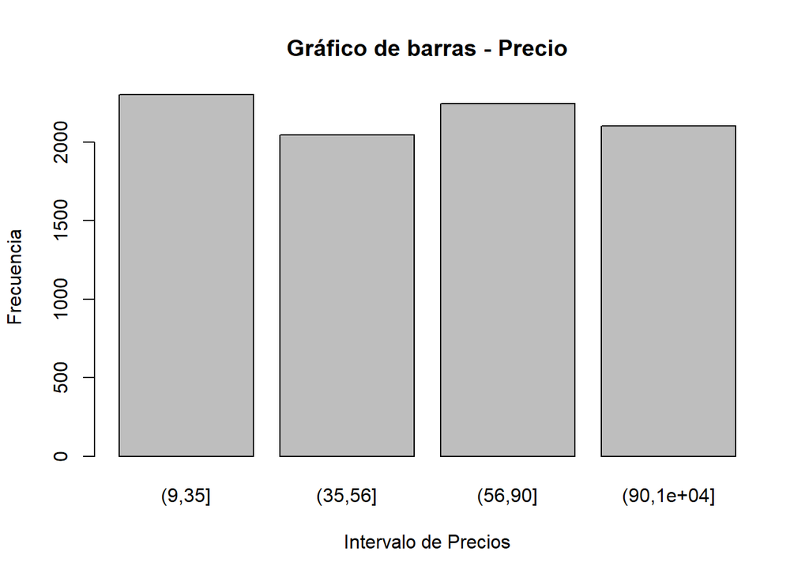

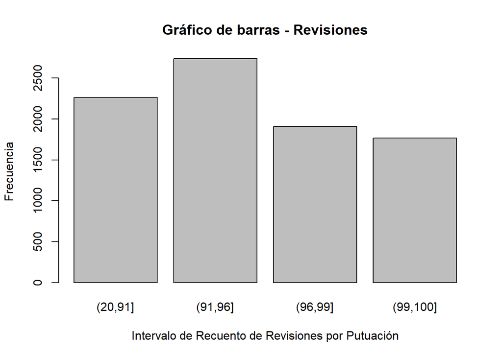

### 1.10.4 d)

- 4. A partir de esta tabla haced un test $\chi^2$ de independencia para determinar si las dos variables son independientes, con un nivel de significación del 0.05.

Los valores del test de independencia son:

```
##
##  Pearson's Chi-squared test
##
## data:  tabla_contingencia
## X-squared = 124.67, df = 9, p-value < 2.2e-16
```